# Peltsi

Sirke Piirainen

# 1. Peltosirkkuaineiston muokkaus

## 1.1 Uusien muuttujien laskeminen

Lasketaan uusia muuttujia, jotka tiivistävät aineistoa. Osa muuttujista on “vaihtoehtoisia”, niiden sisältämä tieto saattaa kuulua kahteen eri muuttujaan.

### 1.1.1 Aineisto sisälle ja tarkastelu

```r
getwd()
```

```
## [1] "C:/Users/Sirke Piirainen/OneDrive - University of Helsinki/github_mallinnus/ortolan_bunting"
```

```r
localDir = "."
DataDir = file.path(localDir, "data")
filename1 = file.path(DataDir, "osapop_20002018.csv")
filename2= file.path(DataDir,"keskipisteiden_koordinaatit.csv")
data = read.csv(filename1, sep=";")
koord = read.csv(filename2, sep=";")

names(data)
```

```
##   [1] "id"     "year"   "site"   "agri5"  "area"   "build"  "ndvi"
##   [8] "prec"   "river"  "roads"  "stream" "temp"   "terri"  "spnum"
##  [15] "X10"    "X50"    "X55"    "X60"    "X63"    "X90"    "X94"
##  [22] "X95"    "X1110"  "X1120"  "X1140"  "X1141"  "X1142"  "X1210"
##  [29] "X1211"  "X1220"  "X1230"  "X1310"  "X1320"  "X1330"  "X1400"
##  [36] "X1510"  "X1540"  "X1545"  "X1600"  "X1601"  "X1602"  "X1603"
##  [43] "X1605"  "X1700"  "X1750"  "X1800"  "X1810"  "X1900"  "X2110"
##  [50] "X2120"  "X2130"  "X2140"  "X2150"  "X2160"  "X2180"  "X2185"
##  [57] "X2190"  "X2195"  "X2196"  "X2197"  "X2200"  "X2400"  "X2410"
##  [64] "X2420"  "X2430"  "X2500"  "X2600"  "X3110"  "X3120"  "X3130"
##  [71] "X3140"  "X3150"  "X3160"  "X3180"  "X3190"  "X3210"  "X3310"
##  [78] "X4030"  "X4110"  "X4120"  "X4210"  "X4220"  "X4300"  "X4390"
##  [85] "X4520"  "X4530"  "X4610"  "X4620"  "X4800"  "X4810"  "X4900"
##  [92] "X4901"  "X4902"  "X4903"  "X4904"  "X5100"  "X5101"  "X5102"
##  [99] "X5103"  "X5104"  "X5105"  "X5106"  "X5107"  "X5108"  "X5109"
```

[output cut: 21 more lines]

Muuttujien selitykset:

id = kunkin osapopulaation yksilöivä id-numero (vuosien 2000-2017 välillä tehdyt havaintoryppäät, jotka tulkitaan lauluryhmäksi)

site = osapopulaation sijainti

agri5 = osapopulaation keskipisteen ympärille piirretyn 5 km säteen omaavan ympyrän sisälle jäävän maaseutu-maanpeitteen osuus (aineisto: Corine)

area = kunkin osapopulaation pinta-ala neliömetreissä (osapopulaatioksi tulkittujen havaintojen ympärille piirretty 300 metrin bufferi)

build = rakennusten lukumäärä osapopulaation alueella

river = jokien pituus metreinä

roads = teiden pituus metreinä

stream = purojen pituus metreinä

ndvi = Guinean edellistalven kasvillisuus-indeksi

prec = edellisen kesän (21.5-15.7) päivittäisten keskisadantojen keskiarvo osapopulaation alueella

temp = edelliskesän lämpötilat

terri = reviirien lukumäärä osapopulaation alueella vuosittain

spnum = viljelykasvien lukumäärä (ilman luokkaa 99999, eli ei tietoa)

X… = viljelykasviluokkien osuudet, Huom! muuttuja X99999 on “ei tietoa viljelykasvista”

Eri viljelykasveja on mukana yli toistasataa! Suurin osa tietysti nollaa.

Koordinaatit tulivat eri tiedostosta:

```r
head(koord)
```

```
##          X       Y id                             alue
## 1 416510.3 6714497  1              Maentsaelae, Purola
## 2 451751.2 6740100  2         Orimattila, Korpistonoja
## 3 422221.1 6725615  3          Pukkila, Savijoki, ydin
## 4 423032.5 6727459  4                 Pukkila, Suomela
## 5 422232.1 6722946  5               Pukkila, Naarkoski
## 6 419943.0 6719118  6 Pukkila, Maettaehistae, Suokanta
```

### 1.1.2 Shannon-Wienerin indeksi

Shannon-Wienerin indeksin laskeminen viljylykasvidiversiteetille. Mukaan laskuihin on (kai) otettava muuttuja ‘99999’ eli ‘ei tietoa kasvilajista’ koska muuten osuudet eivät summaudu yhteen.

```r
#lisataan shannon-wiener muuttuja
data<-mutate(data, shan = diversity(data[,15:248],index="shannon"))
```

### 1.1.3 Viljelykasvilajien lukumäärä

Kasvilajien lukumäärä (‘99999’ mukana). Huomioi, että todellisuudessa tämä muuttuja voi kuvastaa vain EU-tukiryhmien moninaisuutta, lajithan voivat olla samaa nurmea koko ajan mutta eri kategorioissa.

```r
#kasvilajien lukumaara
data<-mutate(data, snum= rowSums(data[,15:248]>0))
```

### 1.1.4 Viljelykasvilajien osuudet peltopinta-alasta

Alustava jaottelu kymmeneen ryhmään:

```r
#listataan ensi mita muuttujia menee mihinkin ryhmaan

eitietoa<-c("X99999")

avomaavih<-c("X5148","X3210","X50","X55","X3110","X3120","X3130","X3140","X3150","X3160","X3180","X3190","X3310","X5100","X5103","X5104","X5105","X5106","X5107","X5108","X5109","X5111","X5112","X5113","X5115","X5116","X5117","X5119","X5120","X5121","X5124","X5125","X5128","X5129","X5134","X5140","X5143","X5146","X5149","X5150","X5157","X5165","X5173","X5197","X5198","X5816","X9630")

erikois<-c("X4900","X4901","X4902","X4903","X4904","X9640","X9642") #lähinnä ruokohelpi (4900)

marjat<-c("X5210","X5213","X5220","X5221","X5301","X5302","X5303","X5304","X5307","X5310","X5311","X5318","X5319","X5400","X5410","X5420","X5441","X5451","X5500","X5510","X5512","X5530","X5534","X7210")

viljat<-c("X5853","X5831","X1211","X2190","X2195","X1140","X10","X1120","X1142","X1210","X1220","X1310","X1320","X1330","X1400","X1510","X1540","X1545","X1600","X1601","X1602","X1603","X1605","X1700","X1750","X1800","X1810","X1900")

mausteet<-c("X4800","X4810","X5152","X5806","X5824","X5842","X5843","X5846","X5850","X5851")

nurmet<-c("X6051","X2420","X2196","X2197","X9050","X9060","X9061","X9421","X94","X95","X90","X63","X60","X6050","X6060","X6111","X6112","X6113","X6114","X6121","X6122","X6123","X6124","X6125","X6210","X6220","X6221","X6230","X6300","X6301","X6302","X6400","X6402","X6542","X6545","X6546","X6550","X6561","X6562","X6563","X6565","X6600","X6700","X6710","X6720","X7110","X9100","X9101","X9102","X9110","X9111","X9400","X9401","X9402","X9403","X9404","X9405","X9406","X9407","X9408","X9412","X9413","X9422","X9423","X9424","X9430","X9440","X9460","X9600","X9620","X9700","X9710","X9720","X9801","X9810","X9811","X9812","X9800","X9820","X9802","X9803",    "X9804","X9805",    "X9806","X9807","X9808")

syysviljat<-c("X1110","X1141","X1230","X4120","X4220")

valkuais<-c("X2110","X2120","X2130","X2140","X2150","X2160","X2180","X2185","X2200","X2400","X2410","X2430","X2500","X2600","X5101","X5102")

oljy<-c("X4390","X4030","X4110","X4210","X4300","X4520","X4530","X4610","X4620","X8021")
```

Neonikotinoideihin yhdistettävät kasvilajit voidaan lajitella vielä lisäksi omaksi ryhmäkseen. Huomioi, että tämän ryhmän lajit löytyvät jo muista ryhmistä.

```r
#jos halutaan potentiaaliset neonikotinoidikasvit erikseen
neot<-c("X4110","X4120","X4210","X4220","X3210")
```

Lasketaan viljelyosuudet uusille ryhmille:

```r
#valitaan ketjun perusteella sarakkeet ja lasketaan niistä summa uuden sarakkeen alle
data %>% dplyr::select(avomaavih) %>% rowSums(na.rm=TRUE) -> data$vege
data %>% dplyr::select(eitietoa) %>% rowSums(na.rm=TRUE) -> data$unkno
data %>% dplyr::select(erikois) %>% rowSums(na.rm=TRUE) -> data$spec
data %>% dplyr::select(marjat) %>% rowSums(na.rm=TRUE) -> data$fruit
data %>% dplyr::select(viljat) %>% rowSums(na.rm=TRUE) -> data$cere
data %>% dplyr::select(mausteet) %>% rowSums(na.rm=TRUE) -> data$herb
data %>% dplyr::select(nurmet) %>% rowSums(na.rm=TRUE) -> data$gras
data %>% dplyr::select(syysviljat) %>% rowSums(na.rm=TRUE) -> data$wint
data %>% dplyr::select(valkuais) %>% rowSums(na.rm=TRUE) -> data$prot
data %>% dplyr::select(oljy) %>% rowSums(na.rm=TRUE) -> data$oil
#neo erikseen
data %>% dplyr::select(neot) %>% rowSums(na.rm=TRUE) -> data$neo
```

Tarkastellaan yksittäisten viljelykasvilajien osuuksia aineistossa:

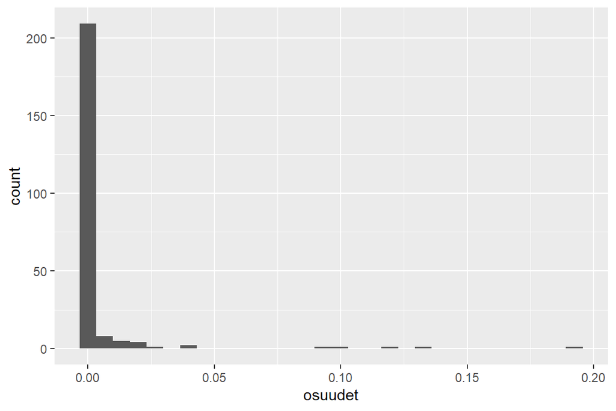

```r
#viljelykasvien keskimääräiset osuudet kaikilta vuosilta
osuudet<-colMeans(data[,15:248])
sp<-names(data[,15:248])
sp<- as.data.frame((cbind(sp,osuudet)),row.names = F)
sp$osuudet<-as.numeric(as.character(sp$osuudet))

#viljelykasvien osuuksien jakauma
ggplot(sp, aes(x=osuudet))+geom_histogram()
```

Vain muutama laji dominoi viljelyosuuksissa.

Yleisimmät viljelykasvit:

```r
#yleisimmät viljelykasvit
sp[order(-osuudet),]
```

```
##         sp      osuudet
## 10   X1120 1.923806e-01
## 21   X1400 1.300782e-01
## 18   X1310 1.219465e-01
## 158  X6121 1.016137e-01
## 19   X1320 9.042679e-02
## 65   X4110 3.935079e-02
## 9    X1110 3.915448e-02
## 195  X9400 2.338377e-02
## 161  X6124 2.164654e-02
## 159  X6122 2.006852e-02
## 17   X1230 1.986871e-02
## 62   X3210 1.848785e-02
## 200  X9405 1.544742e-02
## 67   X4210 1.391087e-02
```

[output cut: 220 more lines]

Yleisimmät lajit ovat kevätvehnä (1120), kaura (1400), rehuohra (1310), monivuotiset kuivaheinä-, säilörehu- ja tuorerehunurmet (6121), mallasohra (1320), kevätrypsi (4110) ja syysvehnä (1110).

Kasviryhmien osuudet:

```r
#kasviryhmien keskimääräiset osuudet kaikilta vuosilta
colMeans(data[,251:260])
```

```
##        vege       unkno        spec       fruit        cere        herb
## 0.028861052 0.010546658 0.003109716 0.004511246 0.543042138 0.011517012
##        gras        wint        prot         oil
## 0.260565160 0.060451286 0.017519724 0.055537205
```

Viljat ja nurmet dominoivat. Öljykasvit ja syysviljat tulevat perässä.

Lasken **Shannonin diversiteetti-indeksin** myös kasviryhmistä. Se saattaa olla järkevämpi mitta kuin kasvikoodeista laskettu indeksi. Sehän saattaa kuvata vain luokittelun kirjoa.

```r
data<-mutate(data, shanG = diversity(data[,251:260],index="shannon"))
```

Jos halutaan vielä tiivistää viljelykasviryhmiä, voidaan lajitella kasvit kahteen ryhmään. Toinen ryhmä (open) käsittää kasvit, jotka ovat keväällä peltosirkkujen pesimäaikaan vasta kylvövaiheessa (tai lyhyellä oraalla?). Toinen ryhmä (cover) käsittää kasvit, jotka ovat keväällä jo pidemmällä kasvussa ja niiden peittävyys on suurempi.

```r
#jos halutaan vielä tiivistää viljelykasveja
data<-mutate(data, open = cere+vege+oil+prot) # entäpä 9999?
data<-mutate(data, cover = gras+wint) #pitäisikö vielä lisätä herb, fruit ja spec (ruokohelpi)? Näiden ryhmien osuus on pieni. Itseasiassa näillä ei ole väliä koska käytän malleissa vain open muuttujaa.
```

Huomaa, että open ja cover ovat käytännössä toistensa vastakohdat eli summautuvat melkeinpä yhteen.

### 1.1.5 Pienimuotoisten rakenteiden tiheys

Lasketaan rakennusten, teiden, purojen ja jokien tiheys suhteessa osapopulaation pinta-alaan.

```r
#muutetaan pinta-ala neliökilometreiksi
data$area=data$area/1000000
data<-mutate(data, Abuild = (build/area))
data<-mutate(data, Ariver = (river/area))
data<-mutate(data, Astream = (stream/area))
data<-mutate(data, Aroad =(roads/area))
```

## 1.2 Aineiston siistiminen

Karsitaan yksittäiset viljelykasvisarakkeet aineistosta pois, lisätään osapopulaatioiden koordinaatit ja poistetaan aineistosta kaikki ne vuodet, jolloin osapopulaatiota ei käyty tarkistamassa.

```r
data<-data[,c(1:2,4:5,7:8,12:13,249:250,261:268)]

#koordinaatit
koord=dplyr::select(koord,id,X,Y)
data<-left_join(data,koord,by="id")

names(data)
```

```
##  [1] "id"      "year"    "agri5"   "area"    "ndvi"    "prec"    "temp"
##  [8] "terri"   "shan"    "snum"    "neo"     "shanG"   "open"    "cover"
## [15] "Abuild"  "Ariver"  "Astream" "Aroad"   "X"       "Y"
```

```r
#edit! Lisätään vielä muuttuja 'neoPrior' eli edellisen vuoden neoviljely, ennen kuin poistetaan ylimääräiset havainnot
data<-transform(data, NeoPrior = ave(neo, id, FUN = function(x) c(NA, head(x, -1))))

#poista aineistosta paikat, joilla ei ole kayty
data=data %>% drop_na("terri")
```

Mukana on siis vielä 21 (osin vaihtoehtoista) muuttujaa.

Tallennetaan aineisto:

```r
#tallennetaan
write.csv(data,"OrtolanBunting.csv",row.names = F)
```

# 2. Peltosirkkuaineiston analyysi

Tutkimuskysymykset:

1. Peltosirkun häviämisnopeus kasvaa alueen avoimuuden vähentyessä ja eristyneisyyden kasvaessa
2. Peltosirkun häviämisnopeus kasvaa peltoviljelyn muuttuessa viljavaltaisesta nurmivaltaiseksi
3. Peltosirkun häviämisnopeus kasvaa viljelyn monimuotoisuuden vähentyessä
4. Peltosirkun häviämisnopeus kasvaa maiseman pienipiirteisten rakenteiden yksipuolistuessa

## 2.1 Aineiston tarkastelua

Luetaan aineisto sisään ja tarkistetaan, että luokkamuuttujat ovat oikein ja ettei joukossa ole NA:ta:

```r
data<-read.csv("OrtolanBunting.csv")

names(data)
```

```
##  [1] "id"       "year"     "agri5"    "area"     "ndvi"     "prec"
##  [7] "temp"     "terri"    "shan"     "snum"     "neo"      "shanG"
## [13] "open"     "cover"    "Abuild"   "Ariver"   "Astream"  "Aroad"
## [19] "X"        "Y"        "NeoPrior"
```

```r
str(data)
```

```
## 'data.frame':    1474 obs. of  21 variables:
##  $ id      : int  3 122 126 130 138 139 140 144 145 147 ...
##  $ year    : int  2000 2000 2000 2000 2000 2000 2000 2000 2000 2000 ...
##  $ agri5   : num  0.46 0.44 0.37 0.35 0.53 0.48 0.39 0.23 0.23 0.51 ...
##  $ area    : num  2.964 1.021 2.111 1.187 0.192 ...
##  $ ndvi    : num  0.441 0.441 0.441 0.441 0.441 0.441 0.441 0.441 0.441 0.441 ...
##  $ prec    : num  0.775 0.784 0.918 0.918 0.849 0.849 0.772 0.651 0.889 0.849 ...
##  $ temp    : num  17.3 17.5 17.4 17.4 17.5 ...
##  $ terri   : int  20 6 12 3 0 3 11 0 5 0 ...
##  $ shan    : num  2.33 1.4 2.18 1.83 1.68 ...
##  $ snum    : int  20 9 12 14 7 8 17 7 18 9 ...
##  $ neo     : num  0.0228 0 0.0628 0.1136 0.058 ...
##  $ shanG   : num  1.083 0.553 0.959 1.276 0.807 ...
##  $ open    : num  0.577 0.806 0.74 0.784 0.799 ...
##  $ cover   : num  0.419 0.176 0.26 0.215 0.201 ...
##  $ Abuild  : num  66.1 105.8 27 32.9 0 ...
##  $ Ariver  : num  802 0 0 0 2564 ...
##  $ Astream : num  1481 1710 2009 2129 537 ...
##  $ Aroad   : num  4410 5641 3332 2956 2928 ...
##  $ X       : num  422221 426751 371664 366068 425435 ...
##  $ Y       : num  6725615 6725480 6702677 6700163 6728051 ...
##  $ NeoPrior: num  NA NA NA NA NA NA NA NA NA NA ...
```

```r
summary(data)
```

```
##        id             year          agri5             area
##  Min.   :  1.0   Min.   :2000   Min.   :0.0400   Min.   :0.1673
##  1st Qu.: 67.0   1st Qu.:2005   1st Qu.:0.2725   1st Qu.:0.3125
##  Median :145.0   Median :2011   Median :0.3800   Median :0.6009
##  Mean   :142.3   Mean   :2011   Mean   :0.3784   Mean   :0.7988
##  3rd Qu.:219.0   3rd Qu.:2016   3rd Qu.:0.4800   3rd Qu.:0.9628
##  Max.   :279.0   Max.   :2018   Max.   :0.7700   Max.   :2.9829
##
##       ndvi             prec            temp           terri
##  Min.   :0.4150   Min.   :0.624   Min.   :11.24   Min.   : 0.000
##  1st Qu.:0.4170   1st Qu.:1.718   1st Qu.:13.53   1st Qu.: 0.000
##  Median :0.4300   Median :2.017   Median :14.22   Median : 1.000
##  Mean   :0.4307   Mean   :2.052   Mean   :14.37   Mean   : 3.005
##  3rd Qu.:0.4410   3rd Qu.:2.374   3rd Qu.:15.29   3rd Qu.: 4.000
##  Max.   :0.4580   Max.   :4.091   Max.   :17.83   Max.   :26.000
##
##       shan            snum            neo              shanG
##  Min.   :0.000   Min.   : 0.00   Min.   :0.00000   Min.   :0.0000
##  1st Qu.:1.233   1st Qu.: 6.00   1st Qu.:0.00000   1st Qu.:0.6464
##  Median :1.565   Median : 8.00   Median :0.00000   Median :0.8396
##  Mean   :1.527   Mean   : 9.18   Mean   :0.07017   Mean   :0.8317
##  3rd Qu.:1.874   3rd Qu.:12.00   3rd Qu.:0.09912   3rd Qu.:1.0594
##  Max.   :2.622   Max.   :28.00   Max.   :1.00000   Max.   :1.7875
##
##       open            cover            Abuild           Ariver
##  Min.   :0.0000   Min.   :0.0000   Min.   :  0.00   Min.   :   0.0
##  1st Qu.:0.5157   1st Qu.:0.1569   1st Qu.: 25.58   1st Qu.:   0.0
##  Median :0.6841   Median :0.2916   Median : 38.28   Median :   0.0
##  Mean   :0.6455   Mean   :0.3331   Mean   : 46.47   Mean   : 422.2
##  3rd Qu.:0.8271   3rd Qu.:0.4571   3rd Qu.: 60.38   3rd Qu.: 452.4
##  Max.   :1.0000   Max.   :1.0000   Max.   :250.45   Max.   :5037.7
##
##     Astream          Aroad             X                Y
##  Min.   :    0   Min.   :    0   Min.   :219788   Min.   :6659254
##  1st Qu.: 1344   1st Qu.: 3529   1st Qu.:300620   1st Qu.:6712307
##  Median : 2148   Median : 4293   Median :387254   Median :6725480
##  Mean   : 2397   Mean   : 4513   Mean   :367533   Mean   :6760542
##  3rd Qu.: 3250   3rd Qu.: 5463   3rd Qu.:423478   3rd Qu.:6769346
##  Max.   :12444   Max.   :11452   Max.   :678915   Max.   :7193444
##
##     NeoPrior
##  Min.   :0.00000
##  1st Qu.:0.00000
##  Median :0.00000
##  Mean   :0.06900
##  3rd Qu.:0.09777
##  Max.   :1.00000
##  NA's   :37
```

```r
#tarkasta kaikkien luokkien muoto
data$id<-as.factor(data$id)
#luodaan vuodelle oma faktori-muuttuja
data$fyear<-as.factor(data$year)
#pinta-alalle myös oma log-muunnettu muuttuja
data$Larea=log(data$area)
```

Huomaa, että pinta-ala on tässä kohtaa muuttunut neliökilometreiksi.

### 2.1.1 Poikkeavia havaintoja

Tarkastellaan havaintoja yksitellen, onko mukana virheitä tai poikkeavia havaintoja:

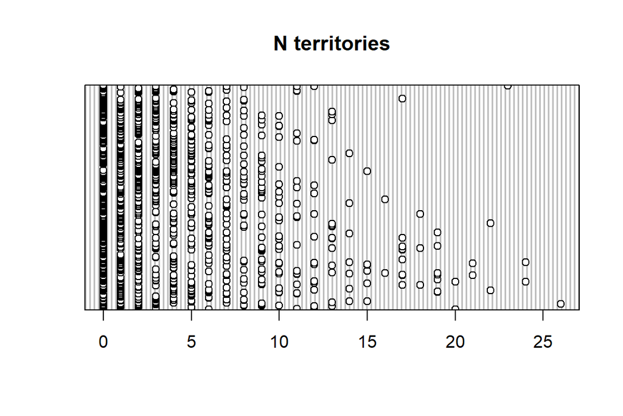

```r
#outliers
dotchart(data$terri, main= "N territories")
```

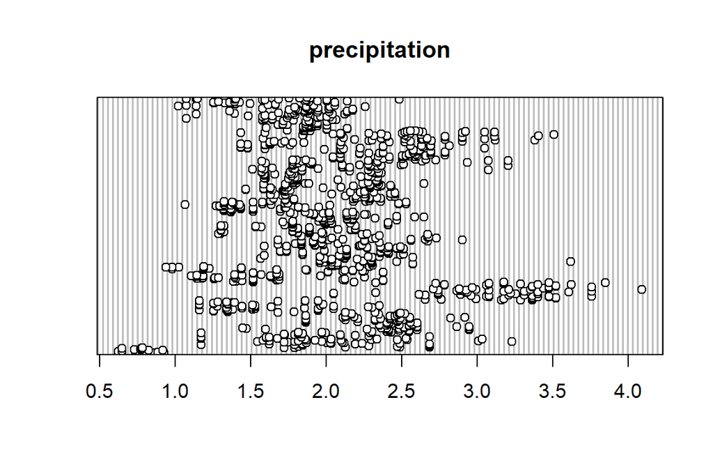

```r
dotchart(data$prec, main= "precipitation")
```

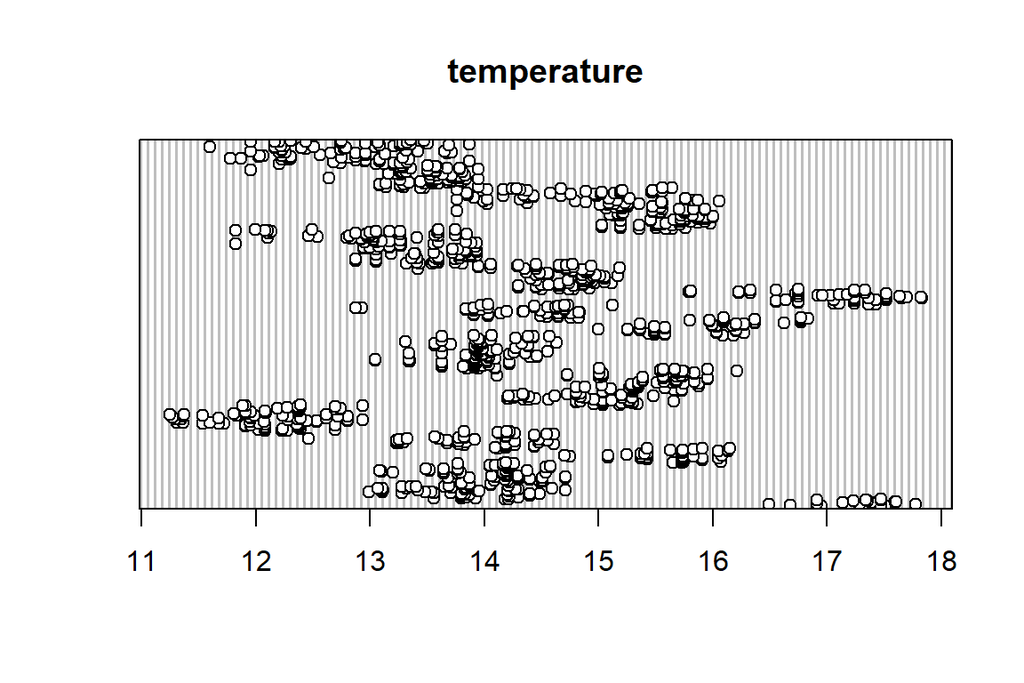

```r
dotchart(data$temp, main= "temperature")
```

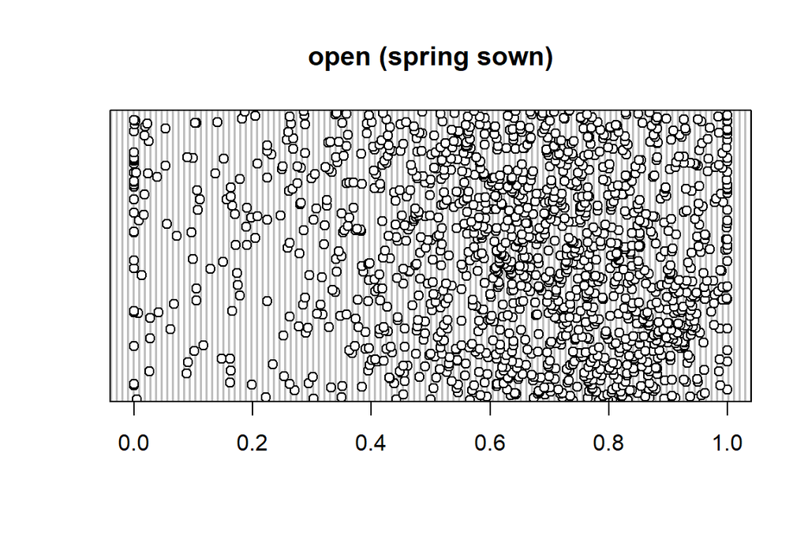

```r
dotchart(data$open, main= "open (spring sown)")
```

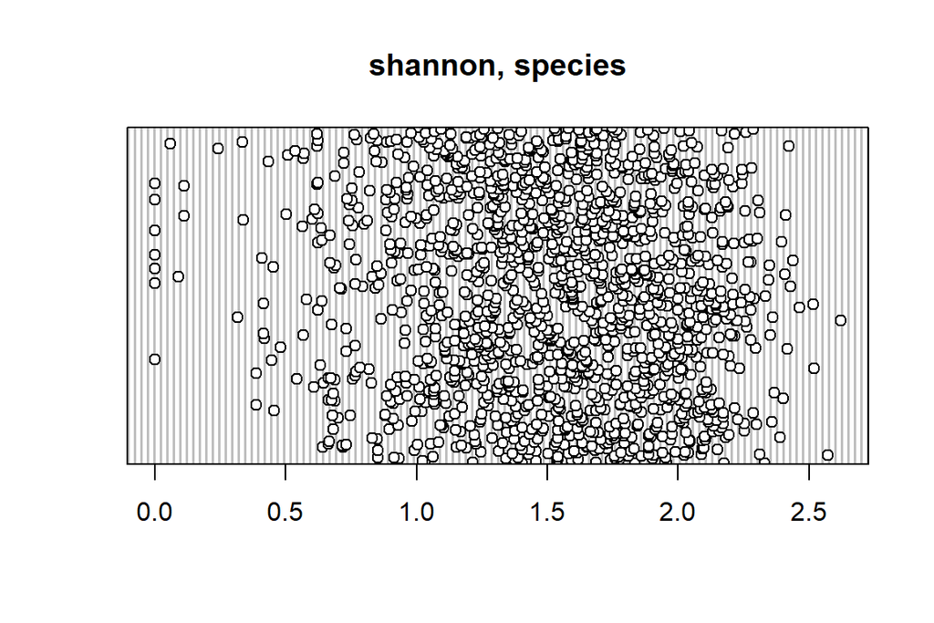

```r
dotchart(data$shan, main= "shannon, species")
```

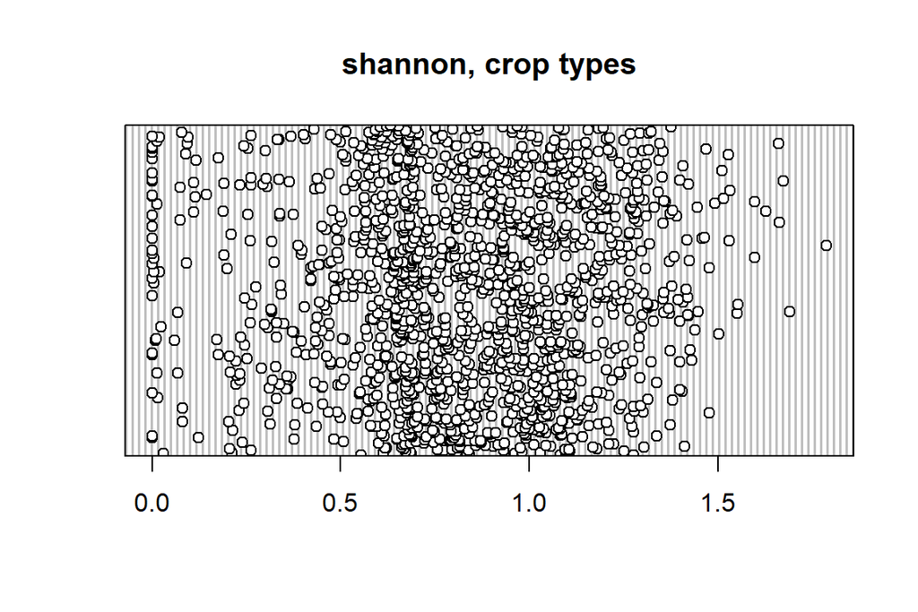

```r
dotchart(data$shanG, main= "shannon, crop types")
```

Kuinka monta reviiriä per osapopulaatio?

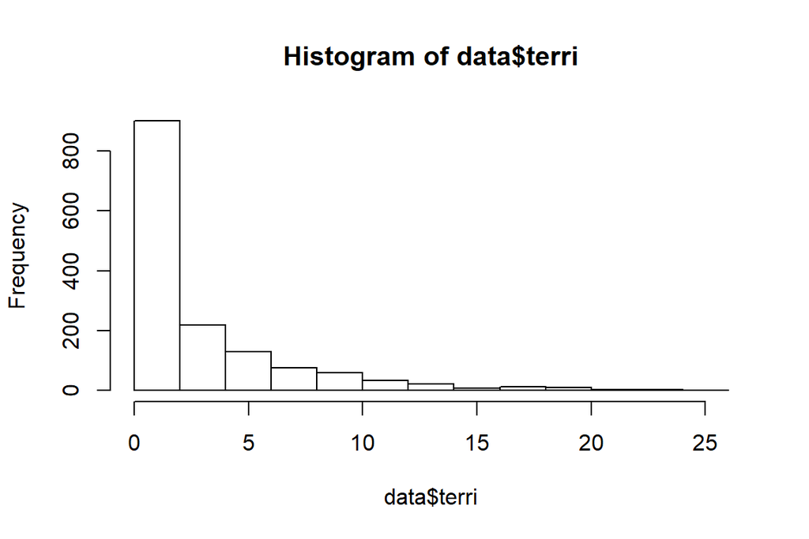

```r
hist(data$terri)
```

```r
table(data$terri)
```

```
##
##   0   1   2   3   4   5   6   7   8   9  10  11  12  13  14  15  16  17
## 540 213 147 116 103  72  58  43  32  34  25  19  14  14   7   6   2   9
##  18  19  20  21  22  23  24  26
##   3   7   2   2   2   1   2   1
```

Aineistossa on muutama “MEGA”osapopulaatio. Suurimmaksi osaksi osapopulaatiot ovat tyhjiä tai niillä on muutama reviiri.

Kuinka monta käyntikertaa per osapopulaatio?

```r
sort(table(data$id))
```

```
##
## 160 161 162 225 227 274  89 106 111 134 135 136 141 165 167 169 180 201
##   1   1   1   1   1   1   2   2   2   2   2   2   2   2   2   2   2   2
## 203 204 205 206 207 208 209 210 211 212 213 214 215 216 217 218 219 220
##   2   2   2   2   2   2   2   2   2   2   2   2   2   2   2   2   2   2
## 221 222 223 226 228 229 230 239 268  23  26  44  79  83  84  85  90  91
##   2   2   2   2   2   2   2   2   2   3   3   3   3   3   3   3   3   3
##  92  94  95  96  97  98  99 100 101 102 103 104 107 108 109 110 113 114
##   3   3   3   3   3   3   3   3   3   3   3   3   3   3   3   3   3   3
## 117 123 124 125 137 142 150 164 166 168 179 184 185 189 190 224 231 232
##   3   3   3   3   3   3   3   3   3   3   3   3   3   3   3   3   3   3
## 259 261 264 267 269 270 272 275 276 278  24  31  35  46  47  48  49  50
##   3   3   3   3   3   3   3   3   3   3   4   4   4   4   4   4   4   4
##  51  53  54  55  56  57  58  59  60  61  62  63  64  65  66  67  68  69
##   4   4   4   4   4   4   4   4   4   4   4   4   4   4   4   4   4   4
```

[output cut: 18 more lines]

Muutamalla osapopulaatiolla on käyty vain kerran.

### 2.1.2 Riippuvuussuhteita

Tarkastellaan muuttujia suhteessa toisiinsa:

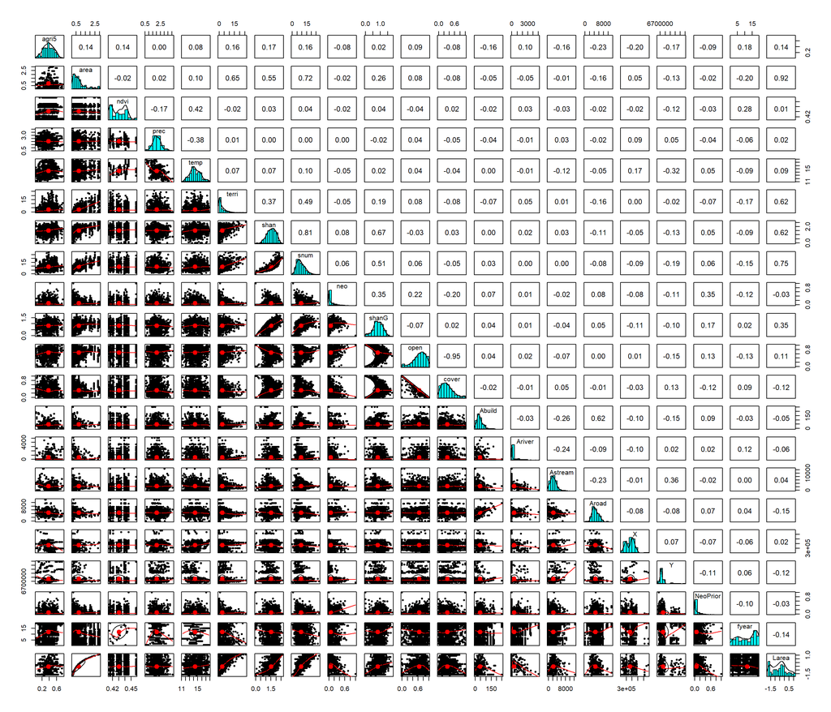

```r
#relationships
pairs.panels(data[,c(3:23)])
```

Reviirien lukumäärällä (terri) ja Shannon-Wienerin indeksillä (shan ja shanG) sekä lajien lukumäärällä (snum) on suht vahva korrelaatio. Shan mittaa viljelykasvilajien (-koodien) monimuotoisuutta. ShanG puolestaan viljelykasviryhmien monimuotoisuutta. Snum mittaa vain viljelykasvilajien (-koodien) lukumäärää. Näistä fiksuin ShanG. Ottaahan offsettina käytetty pinta-ala huomioon sen, että isommalla osapopulaatiolla voi olla enemmän tilaa viljelyskasveille ja sitä kautta isompi monimuotoisuus?

Maatalousmaiseman osuus (agri5) (ja jokien tiheys) on positiivisesti korreloitunut reviirimäärän kanssa. Teiden ja rakennusten tiheys sen sijaan negatiivisesti. Eihän pinta-alan vaikutus tule kahteen kertaan huomioiduksi, jos tieden, jokien, rakennusten ja ojien **tiheydessä** jo huomioidaan pinta-ala?

Vuosi on negatiivisesti korreloitunut reviirimäärien kanssa.

Keväällä kylvettävien kasvien osuus (open) ja keväällä pidemmällä oraalla olevien kasvien (cover) osuudet ovat toistensa vastakohdat.

### 2.1.3 Lisää plottailua

Katsotaan reviirien määrän kehitystä kullakin osapopulaatiolla:

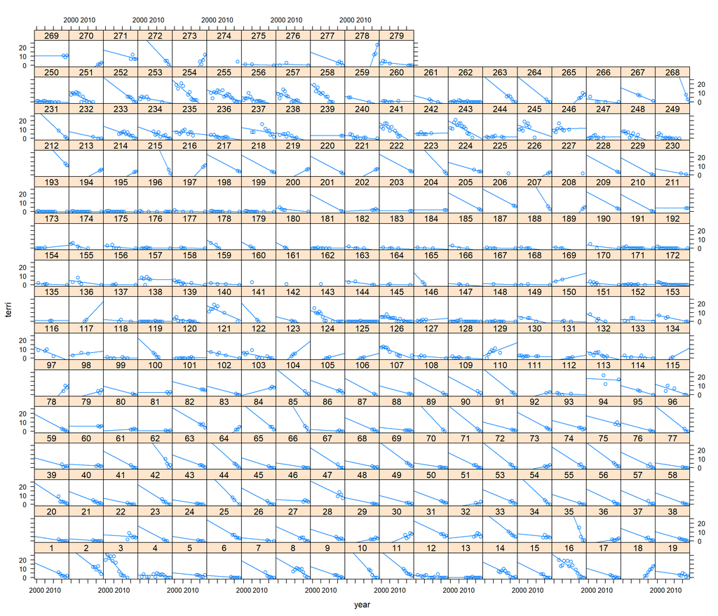

```r
#plottailua
xyplot(terri~year|id, data=data, type = c("p", "r"))
```

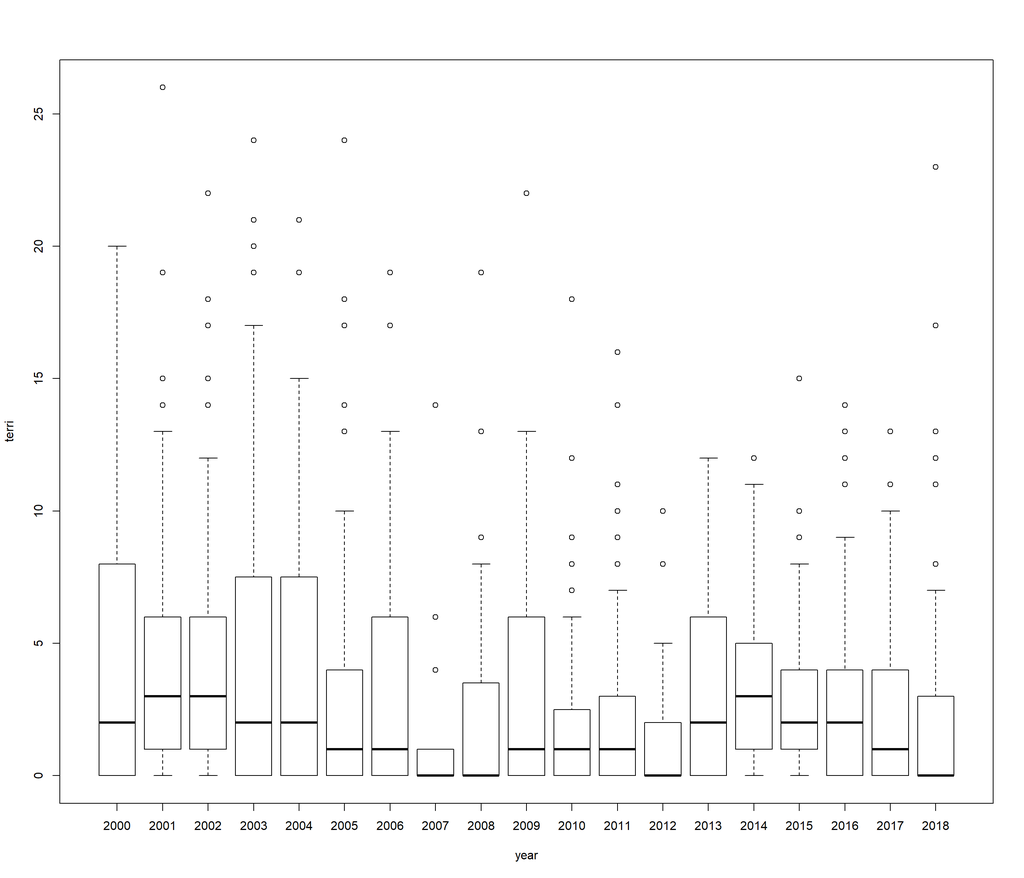

```r
boxplot(terri~year, data=data)
```

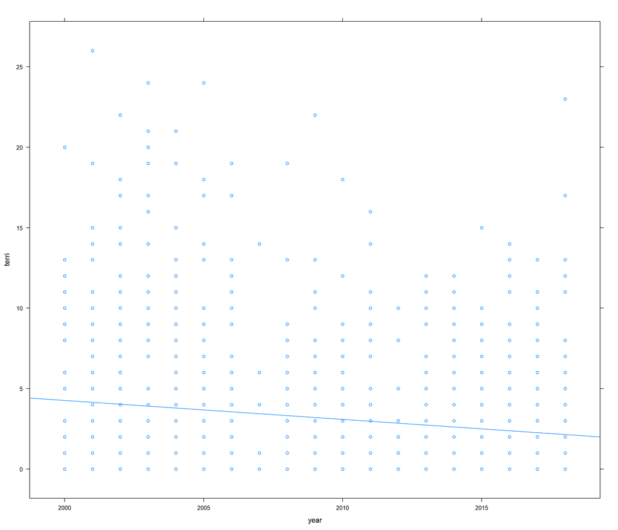

```r
xyplot(terri~year, data=data, type = c("p", "r"))
```

Vuosien välinen trendi näyttäisi yleisesti olevan laskeva ja osapopulaatioiden välillä on suuriakin eroja. Osapopulaatio siis random-tekijäksi, joka säätelee vuoden vaikutusta (ja ryhmittää muutenkin koko aineiston). Eli tavallaan random-tekijänä osapopulaation ja vuoden välinen interaktio (siis random intercept ja slope). (sekava selitys..)

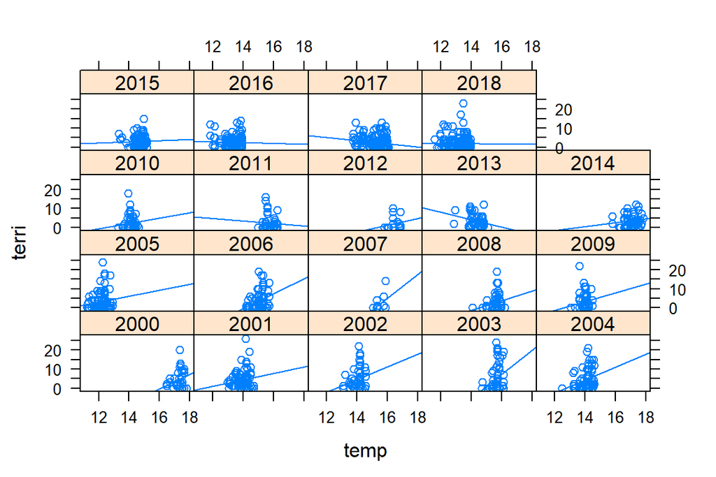

```r
xyplot(terri~temp|fyear, data=data, type = c("p", "r"))
```

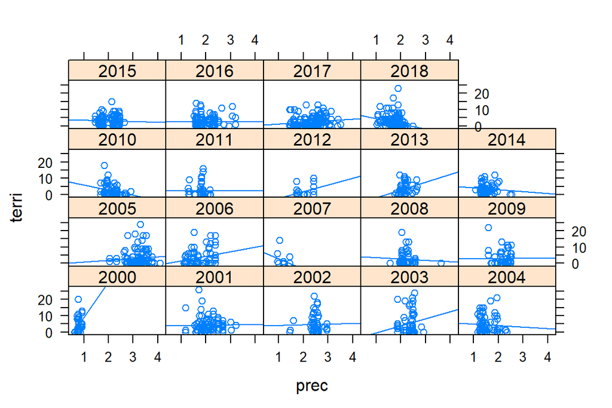

```r
xyplot(terri~prec|fyear, data=data, type = c("p", "r"))
```

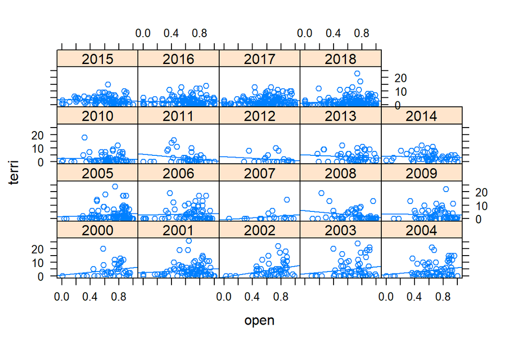

```r
xyplot(terri~open|fyear, data=data, type = c("p", "r"))
```

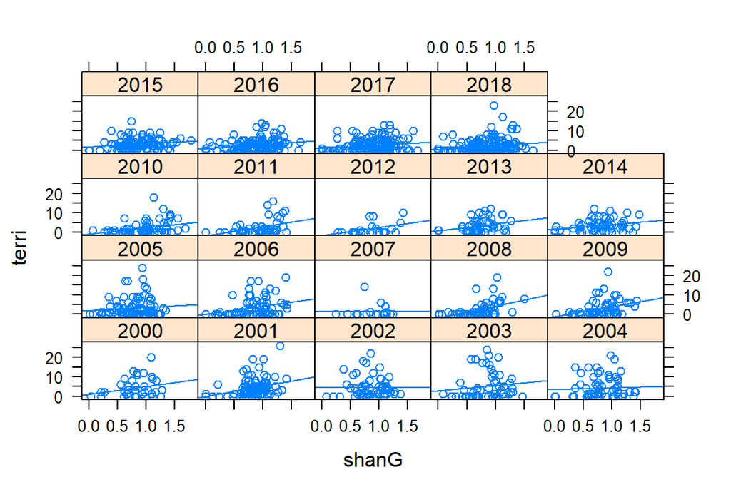

```r
xyplot(terri~shanG|fyear, data=data, type = c("p", "r"))
```

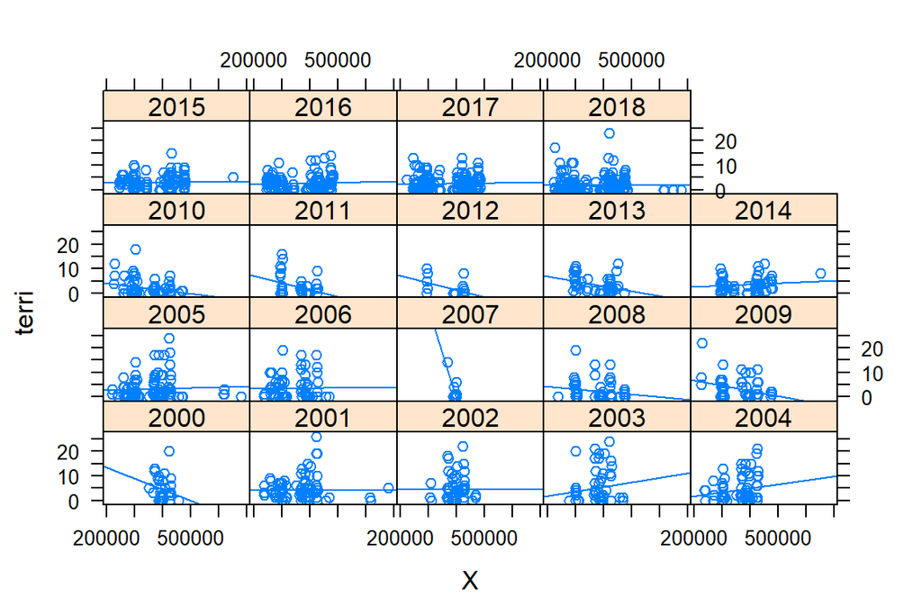

```r
xyplot(terri~X|fyear, data=data, type = c("p", "r"))
```

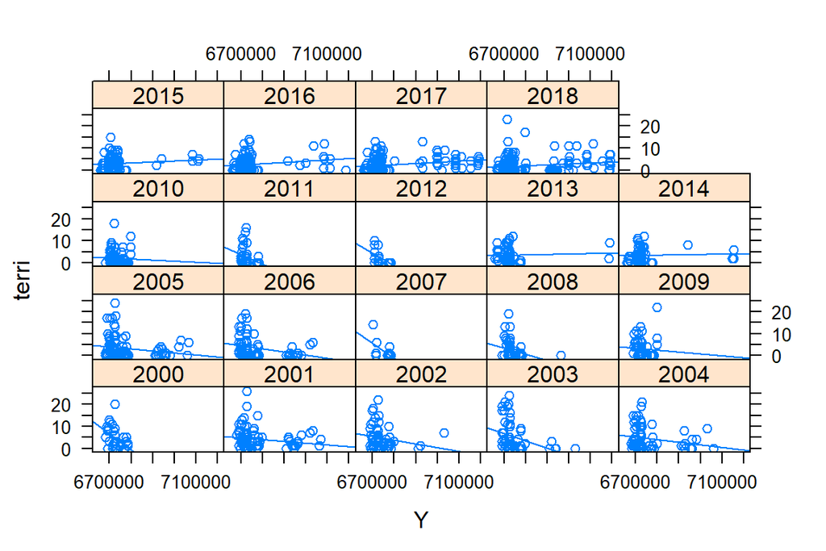

```r
xyplot(terri~Y|fyear, data=data, type = c("p", "r"))
```

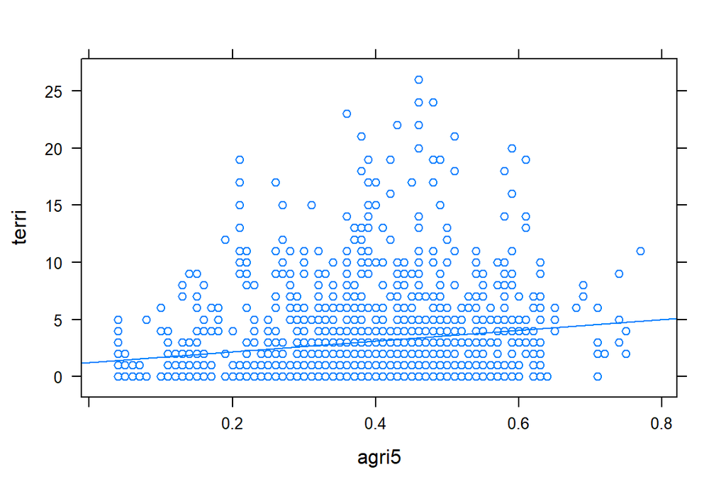

```r
xyplot(terri~agri5, data=data, type = c("p", "r"))
```

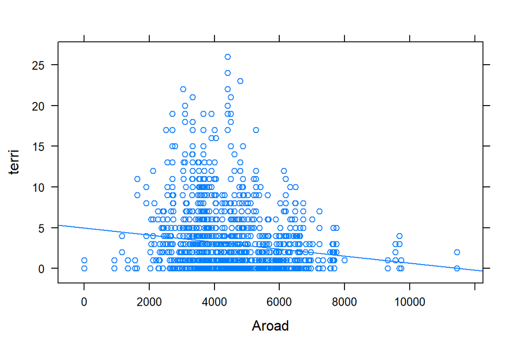

```r
xyplot(terri~Aroad, data=data, type = c("p", "r"))
```

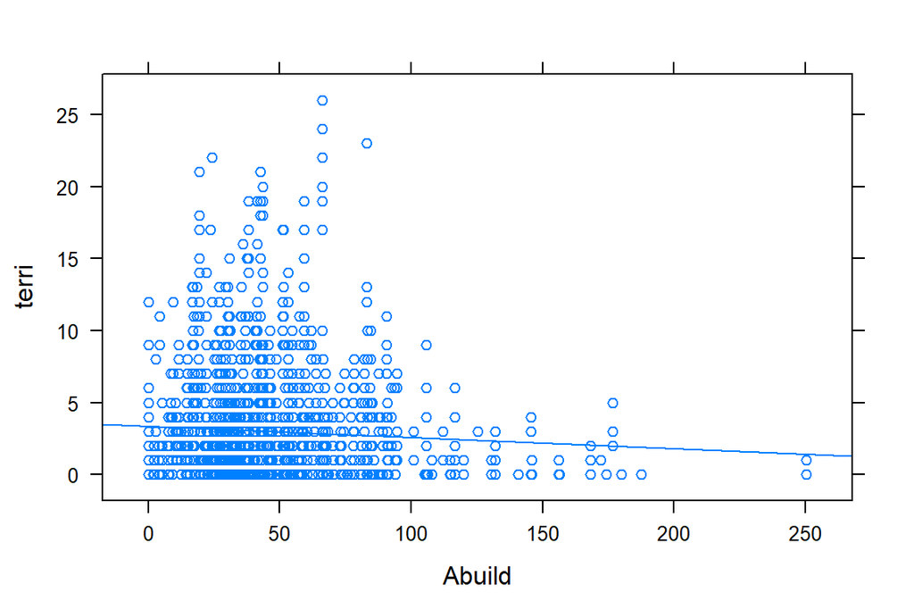

```r
xyplot(terri~Abuild, data=data, type = c("p", "r"))
```

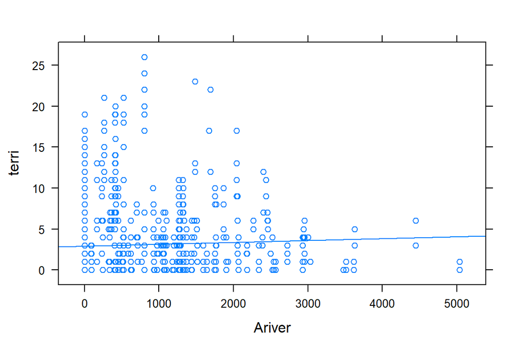

```r
xyplot(terri~Ariver, data=data, type = c("p", "r"))
```

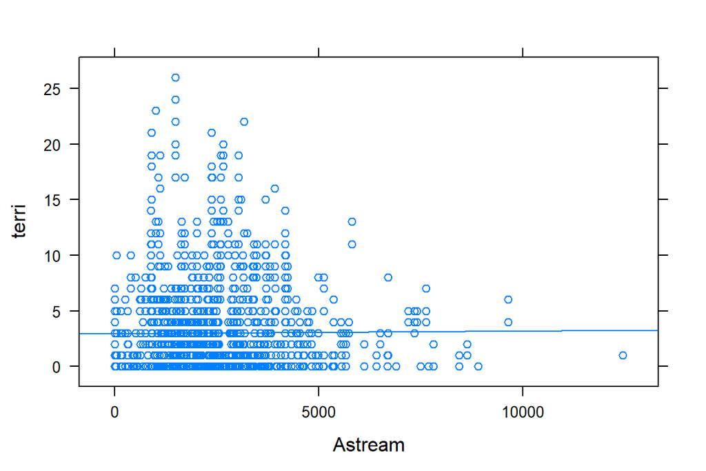

```r
xyplot(terri~Astream, data=data, type = c("p", "r"))
```

## 2.2 Mallit

Peruspiirteittäin suunniteltiin mallit näin:

M1 = year

M2 = year + kov

M3 = year + kov + weather x year

M4 = year + kov + pelto x year

M5 = year + kov + weather x year + pelto x year

Kov(ariaatit) tarkoittaa SSS, agri5 ja koordinaatteja. (“pakolliset kovariaatit”)  
Weather tarkoittaa sadantaa ja lämpötilaa.  
Pelto tarkoittaa shannon-indeksiä ja avoimen maan osuutta (open).

### 2.2.1 Nested/crossed, hierarchical ja muita ajatuksia

```r
#Aksun esimerkit (näissä mukana NDVI):
#m1=glmmTMB(N ~Year + (1|fYear) + (1|Site), family=nbinom2, data=Embhor)
#m2=glmmTMB(N ~SSS + Landscape + X + Y + X*Y + Year + (1|fYear) + (1|Site), family=nbinom2, data=Embhor)
#m3=glmmTMB(N ~SSS + Landscape + X + Y + X*Y + Year*Temp + Year*Rain + Year*NDVI + (1|fYear) + (1|Site), family=nbinom2, data=Embhor)
#m4=glmmTMB(N ~SSS + Landscape + X + Y + X*Y + Year*Cropdiv + Year*Plough + (1|fYear) + (1|Site), family=nbinom2, data=Embhor)
#m5=glmmTMB(N ~SSS + Landscape + X + Y + X*Y + Year*Temp + Year*Rain + Year*NDVI + Year*Cropdiv + Year*Plough + (1|fYear) + (1|Site), family=nbinom2, data=Embhor)
```

Mikään malleista ei aluksi toiminut, koska aineisto oli skaalaamaton. Alla kuitenkin asioita, joita tuli pohdittua ongelmaa selvittäessä:

**Random-muuttujat** Muuttuja ‘id’ eli jokaisen osapopulaaation yksilöivä tunniste on random-muuttuja koska se saattaa sisältää jotain informaatiota, jota fixed-muuttujat eivät sisällä johtuen siitä, että koko populaatio ei ole täydellisesti edustettuna otoksessa.

Määritelmiä siitä, milloin effect on fixed tai random: “Effects are fixed if they are interesting in themselves or random if there is interest in the underlying population. When a sample exhausts the population, the corresponding variable is fixed; when the sample is a small (i.e., negligible) part of the population the corresponding variable is random”.

*Mutta entäpä vuosi?*

Random-efektinä vuosi huomioisi vuosien välisen ajallisen riippuvuuden. Osapopulaatiolla, jolla on monta reviiriä yhtenä vuonna, on suuremmalla todennäköisyydellä monta reviiriä myös seuraavana vuonna.  
Fixed-efektinä se selittäisi reviirien määrässä tapahtuvaa vaihtelua suoraan. Vuodet ovat erilaisia (esim. tapahtumat Afrikassa vaihtelevat) ja jokin asia, jota emme ole tajunneet mitata voi selittyäkin vuodella.

*Muuttuja sekä fixed että random-tekijänä?*

Lue aiheesta [täältä](https://www.theanalysisfactor.com/mixed-models-predictor-both-fixed-random/). Voiko vuosi siis olla fixed effect vain silloin kun se on interaktiossa jonkun toisen muuttujan kanssa?

*Nested or crossed?*

Relatively few mixed effect modeling packages can handle crossed random effects, i.e. those where one level of a random effect can appear in conjunction with more than one level of another effect. (This definition is confusing, and I would happily accept a better one.) A classic example is crossed temporal and spatial effects. If there is random variation among temporal blocks (e.g. years) and random variation among spatial blocks (e.g. sites), and if there is a consistent year effect across sites and “vice versa”, then the random effects should be treated as crossed.

Selkeä vastaus lötyy [täältä](https://stats.stackexchange.com/questions/228800/crossed-vs-nested-random-effects-how-do-they-differ-and-how-are-they-specified).

*Random-muuttujan havaintojen määrä?*

Joillain osapopulaatioilla on käyty vain kerran, joillain taas täydet 19 kertaa. Jos osapopulaatio on random-tekijä täytyy siitä olla havaintoja useampia. Muuten ei pysty arvioimaan ryhmän sisäistä vaihtelua? Katso kysymys [aiheesta](https://stats.stackexchange.com/questions/242821/how-will-random-effects-with-only-1-observation-affect-a-generalized-linear-mixe). Vastaus on kai, että ei haittaa, kunhan vaihtelun saa arvioitua muista osapopulaatioista, joista on useampia havaintoja.

### 2.2.2 GLMM-mallit

#### Ei pinta-alaa mukana

Skaalataan aineisto ja kokeillaan glmm-malleja.

```r
dataS=data %>%mutate_at(c(2:3,5:7,9:21), funs(c(scale(.))))
```

Sovitetaan viisi hypoteesiemme mukaista glmm-mallia ja tulostetaan niiden AICc-taulukko:

```r
M1=glmmTMB(terri ~ year + (1|fyear)+ (1|id), family=nbinom2, data=dataS, REML=FALSE)

M2=glmmTMB(terri ~ Abuild + Astream + Aroad + Ariver + agri5 + X*Y + year + (1|fyear) + (1|id), family=nbinom2, data=dataS, REML=FALSE)

M3=glmmTMB(terri ~ Abuild + Astream + Aroad + Ariver + agri5 + X*Y + year*temp + year*prec  + (1|fyear)  + (1|id), family=nbinom2, data=dataS, REML=FALSE)

M4=glmmTMB(terri ~ Abuild + Astream + Aroad + Ariver + agri5 + X*Y + year*shanG + year*open + (1|fyear) + (1|id), family=nbinom2, data=dataS, REML=FALSE)

M5=glmmTMB(terri ~ Abuild + Astream + Aroad + Ariver + agri5 + X*Y + year*temp + year*prec + year*shanG + year*open + (1|fyear) + (1|id), family=nbinom2, data=dataS, REML=FALSE)

output1<-model.sel(M1,M2,M3,M4,M5)

# AICc Table
output1
```

```
## Model selection table
##    cnd((Int)) dsp((Int)) cnd(yer) cnd(Abl) cnd(ag5) cnd(Arv) cnd(Ard)
## M4     0.5663          +  -0.8019  -0.1125   0.4758   0.2224  0.02702
## M2     0.5660          +  -0.7991  -0.1188   0.4738   0.2146  0.02961
## M5     0.5592          +  -0.8267  -0.1173   0.4772   0.2237  0.02732
## M3     0.5588          +  -0.8219  -0.1235   0.4740   0.2156  0.02997
## M1     0.6560          +  -0.7941
##    cnd(Ast)    cnd(X) cnd(Y) cnd(X:Y)  cnd(prc) cnd(tmp) cnd(prc:yer)
## M4  0.07698  0.007611 0.1559  0.03538
## M2  0.06974 -0.001809 0.1467  0.03523
## M5  0.07590  0.003085 0.1720  0.03745 -0.003492  0.04169     -0.03619
## M3  0.06862 -0.005961 0.1624  0.03704 -0.005096  0.04046     -0.03619
## M1
##    cnd(tmp:yer)  cnd(opn) cnd(shG) cnd(opn:yer) cnd(shG:yer) df    logLik
## M4              -0.003715  0.08700     -0.03606      0.03604 17 -2734.635
## M2                                                           13 -2739.492
## M5      0.05969 -0.006969  0.08651     -0.03482      0.03524 21 -2731.568
## M3      0.05542                                              17 -2736.419
## M1                                                            5 -2763.107
##      AICc delta weight
## M4 5503.7  0.00  0.504
## M2 5505.2  1.54  0.233
## M5 5505.8  2.08  0.178
## M3 5507.3  3.57  0.085
## M1 5536.3 32.56  0.000
## Models ranked by AICc(x)
## Random terms (all models):
## 'cond(1 | fyear)', 'cond(1 | id)'
```

Taulukon mukaan mallit M4 ja M2 ovat parhaimpia, 1.54 AICc yksikön erolla toisistaan.

Aksun tyylin mukaan katsotaan ensin AICdelta=2 rajojen sisällä olevia malleja ja jos niistä parhain on myös yksinkertaisin, voidaan sen olettaa olevan paras. Muut mallit sisältävät lisäksi vain ‘uninformative parameters’. Jos paras malli ei ole yksinkertaisin, laajennetaan tarkastelus AICdelta=4 rajojen sisälle ja tehdään kaikille kriteerin täyttäville malleille model averaging.

Tehdään model averaging M4,M2, M5 ja M3 malleilla:

```r
output2=model.sel(M4,M2,M3,M5)

#tehdään model averaging
summary(model.avg(output2, revised.var = TRUE))
```

```
##
## Call:
## model.avg(object = output2, revised.var = TRUE)
##
## Component model call:
## glmmTMB(formula = terri ~ <4 unique rhs>, data = dataS, family =
##      nbinom2, REML = FALSE, ziformula = ~0, dispformula = ~1)
##
## Component models:
##                                           df   logLik    AICc delta weight
## 1/2/3/4/5/6/7/8/9/10/11/12/13             17 -2734.63 5503.69  0.00   0.50
## 1/2/3/4/5/8/9/10/13                       13 -2739.49 5505.23  1.54   0.23
## 1/2/3/4/5/6/7/8/9/10/11/12/13/14/15/16/17 21 -2731.57 5505.77  2.08   0.18
## 1/2/3/4/5/8/9/10/13/14/15/16/17           17 -2736.42 5507.26  3.57   0.08
##
## Term codes:
##     cond(Abuild)      cond(agri5)     cond(Ariver)      cond(Aroad)
##                1                2                3                4
##    cond(Astream)       cond(open)      cond(shanG)          cond(X)
##                5                6                7                8
##          cond(Y)       cond(year)  cond(open:year) cond(shanG:year)
##                9               10               11               12
##        cond(X:Y)       cond(prec)       cond(temp)  cond(prec:year)
##               13               14               15               16
##  cond(temp:year)
##               17
##
## Model-averaged coefficients:
## (full average)
##                   Estimate Std. Error Adjusted SE z value Pr(>|z|)
## cond((Int))       0.564337   0.097861    0.097942   5.762  < 2e-16 ***
## cond(Abuild)     -0.115762   0.114260    0.114355   1.012  0.31139
## cond(Astream)     0.074395   0.087935    0.088008   0.845  0.39793
## cond(Aroad)       0.027926   0.105118    0.105206   0.265  0.79067
## cond(Ariver)      0.220242   0.081619    0.081687   2.696  0.00701 **
## cond(agri5)       0.475431   0.093014    0.093091   5.107    3e-07 ***
## cond(X)           0.003461   0.085556    0.085627   0.040  0.96776
## cond(Y)           0.157147   0.076756    0.076819   2.046  0.04079 *
## cond(year)       -0.807378   0.058213    0.058260  13.858  < 2e-16 ***
## cond(shanG)       0.059269   0.050089    0.050103   1.183  0.23683
```

[output cut: 16 more lines]

```
## cond(agri5)       0.475431   0.093014    0.093091   5.107    3e-07 ***
## cond(X)           0.003461   0.085556    0.085627   0.040  0.96776
## cond(Y)           0.157147   0.076756    0.076819   2.046  0.04079 *
## cond(year)       -0.807378   0.058213    0.058260  13.858  < 2e-16 ***
## cond(shanG)       0.086877   0.035764    0.035794   2.427  0.01522 *
## cond(open)       -0.004564   0.042720    0.042756   0.107  0.91499
## cond(X:Y)         0.035855   0.063971    0.064024   0.560  0.57546
## cond(shanG:year)  0.035830   0.031959    0.031986   1.120  0.26263
## cond(open:year)  -0.035739   0.037884    0.037916   0.943  0.34590
## cond(temp)        0.041296   0.043730    0.043767   0.944  0.34540
## cond(prec)       -0.004009   0.032706    0.032733   0.122  0.90252
## cond(temp:year)   0.058315   0.040774    0.040808   1.429  0.15301
## cond(prec:year)  -0.036193   0.029189    0.029213   1.239  0.21537
## ---
## Signif. codes:  0 '***' 0.001 '**' 0.01 '*' 0.05 '.' 0.1 ' ' 1
```

Taulukon tulkinta on hieman epäselvää mulle. Taulukkohan vihjaa etteivät interaktiot olisi merkittäviä, mutta mehän halutaan tutkia nimenomaan interaktioita koska ne linkittyvät asioihin, jotka kertovat reviirien lukumäärän vuosittaisesta muutoksesta. Muuttujien tutkiminen ilman interaktiota vuoden kanssa ei ole tässä tapauksessa mielekästä, koska se selittäisi ennemminkin asioita, jotka vaikuttavat reviirien absoluuttiseen lukumäärään, ei muutokseen. Ko,kö?

#### Pinta-ala offsettina:

Edellisissä malleissa ei huomioitu sitä, että osapopulaatiot ovat eri kokoisia. Toki isommilla alueilla on enemmän reviirejä, joten pinta-alan vaikutus huomioitava kaikessa. Toivottavasti se ei kuitenkaan tule huomioitua jo kahdesti pienipiirteisten rakennelmien kohdalla?

```r
M1=glmmTMB(terri ~ year + offset(log(area)) + (1|fyear)+ (1|id), family=nbinom2, data=dataS, REML=FALSE)

M2=glmmTMB(terri ~ Abuild + Astream + Aroad + Ariver + agri5 + X*Y + year + offset(log(area))+ (1|fyear) + (1|id), family=nbinom2, data=dataS,REML=FALSE)

M3=glmmTMB(terri ~ Abuild + Astream + Aroad + Ariver + agri5 + X*Y + year*temp + year*prec  + offset(log(area))+ (1|fyear)  + (1|id), family=nbinom2, data=dataS,REML=FALSE)

M4=glmmTMB(terri ~ Abuild + Astream + Aroad + Ariver + agri5 + X*Y + year*shanG + year*open + offset(log(area))+ (1|fyear) + (1|id), family=nbinom2, data=dataS,REML=FALSE)

M5=glmmTMB(terri ~ Abuild + Astream + Aroad + Ariver + agri5 + X*Y + year*temp + year*prec + year*shanG + year*open + offset(log(area))+ (1|fyear) + (1|id), family=nbinom2, data=dataS,REML=FALSE)

output1<-model.sel(M1,M2,M3,M4,M5)
output1
```

```
## Model selection table
##    cnd((Int)) dsp((Int)) cnd(yer) cnd(off(log(are))) cnd(Abl) cnd(ag5)
## M2      1.193          +  -0.6616                  +  -0.1444   0.3880
## M3      1.187          +  -0.6843                  +  -0.1491   0.3898
## M4      1.189          +  -0.6620                  +  -0.1402   0.3905
## M5      1.183          +  -0.6861                  +  -0.1449   0.3931
## M1      1.298          +  -0.6756                  +
##    cnd(Arv) cnd(Ard) cnd(Ast)    cnd(X) cnd(Y) cnd(X:Y)  cnd(prc) cnd(tmp)
## M2   0.2285   0.1310  0.04368 -0.014080 0.1930  0.05931
## M3   0.2306   0.1329  0.04326 -0.016930 0.2098  0.06031 -0.010680  0.04330
## M4   0.2340   0.1285  0.04744 -0.006935 0.1992  0.05813
## M5   0.2364   0.1302  0.04693 -0.010040 0.2164  0.05923 -0.009548  0.04425
## M1
##    cnd(prc:yer) cnd(tmp:yer) cnd(opn) cnd(shG) cnd(opn:yer) cnd(shG:yer)
## M2
## M3     -0.03575      0.05046
## M4                           -0.01021  0.06157     -0.02562      0.01761
## M5     -0.03582      0.05452 -0.01268  0.06116     -0.02625      0.01725
## M1
##    df    logLik   AICc delta weight
## M2 13 -2677.937 5382.1  0.00  0.644
## M3 17 -2675.134 5384.7  2.57  0.179
## M4 17 -2675.392 5385.2  3.08  0.138
## M5 21 -2672.541 5387.7  5.60  0.039
## M1  5 -2712.916 5435.9 53.75  0.000
## Models ranked by AICc(x)
## Random terms (all models):
## 'cond(1 | fyear)', 'cond(1 | id)'
```

Tässä tapauksessa paras mallivaihtoehto (AICdelta>2) on myös yksinkertaisin. Eli paras malli löytyi suoraan, M2.

Mallin validointi:

```r
#malli uudelleen, ML-asetuksella
M2=glmmTMB(terri ~ Abuild + Astream + Aroad + Ariver + agri5 + X*Y + year + offset(log(area))+ (1|fyear) + (1|id), family=nbinom2, data=dataS)

summary(M2)
```

```
##  Family: nbinom2  ( log )
## Formula:
## terri ~ Abuild + Astream + Aroad + Ariver + agri5 + X * Y + year +
##     offset(log(area)) + (1 | fyear) + (1 | id)
## Data: dataS
##
##      AIC      BIC   logLik deviance df.resid
##   5381.9   5450.7  -2677.9   5355.9     1461
##
## Random effects:
##
## Conditional model:
##  Groups Name        Variance Std.Dev.
##  fyear  (Intercept) 0.01808  0.1345
##  id     (Intercept) 0.97799  0.9889
## Number of obs: 1474, groups:  fyear, 19; id, 277
##
## Overdispersion parameter for nbinom2 family (): 10.6
##
## Conditional model:
##             Estimate Std. Error z value Pr(>|z|)
## (Intercept)  1.19288    0.07686  15.521  < 2e-16 ***
## Abuild      -0.14443    0.08983  -1.608 0.107889
## Astream      0.04368    0.06863   0.636 0.524509
## Aroad        0.13100    0.08255   1.587 0.112538
## Ariver       0.22849    0.06333   3.608 0.000309 ***
## agri5        0.38799    0.07172   5.410 6.31e-08 ***
## X           -0.01408    0.06526  -0.216 0.829248
## Y            0.19301    0.05786   3.336 0.000851 ***
## year        -0.66164    0.05595 -11.826  < 2e-16 ***
## X:Y          0.05931    0.04883   1.215 0.224508
## ---
## Signif. codes:  0 '***' 0.001 '**' 0.01 '*' 0.05 '.' 0.1 ' ' 1
```

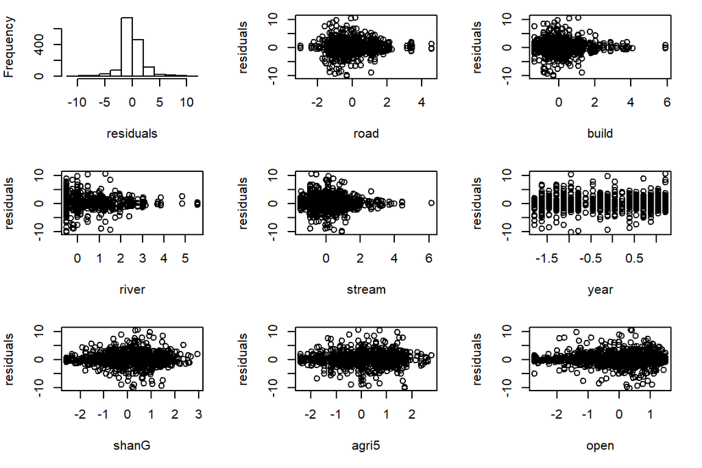

```r
op<-par(mfrow=c(3,3),mar=c(5,4,1,2))
E<-resid(M2)
hist(E, xlab = "residuals",main = "")
plot(dataS$Aroad,E,xlab = "road",ylab="residuals")
plot(dataS$Abuild,E,xlab = "build",ylab="residuals")
plot(dataS$Ariver,E,xlab = "river",ylab="residuals")
plot(dataS$Astream,E,xlab = "stream",ylab="residuals")
plot(dataS$year,E,xlab = "year",ylab="residuals")
plot(dataS$shanG,E,xlab = "shanG",ylab="residuals")
plot(dataS$agri5,E,xlab = "agri5",ylab="residuals")
plot(dataS$open,E,xlab = "open",ylab="residuals")
```

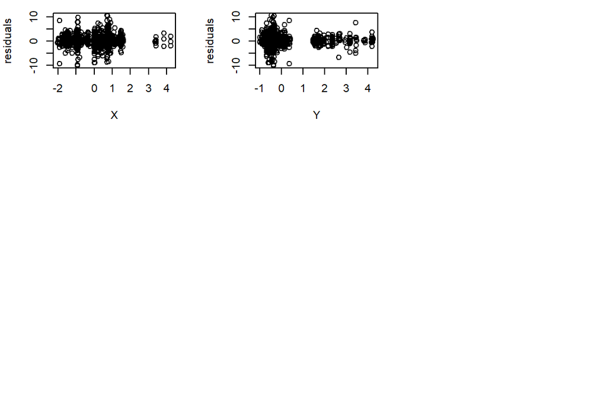

```r
plot(dataS$X,E,xlab = "X",ylab="residuals")
plot(dataS$Y,E,xlab = "Y",ylab="residuals")
par(op)
```

Vaikuttaisi siltä, että ainoita merkitseviä tekijöitä ovat vuosi, agri5 , jokien tiheys ja Y-koordinaatti.

Residuaalien tulkinta on mulla vähän hakusessa.

Huom! Offset voisi kai olla myös argumentti funktiolle, eikä muuttuja niinkuin tässä. Vaihtoehtoa kokeillaan myöhemmin.

#### Pinta-ala kovariaattina:

Samat mallit mutta niin, että pinta-ala onkin oma kovariaattinsa.

```r
M1=glmmTMB(terri ~ year + log(area) + (1|fyear)+ (1|id), family=nbinom2, data=dataS, REML=FALSE)

M2=glmmTMB(terri ~ Abuild + Astream + Aroad + Ariver + agri5 + X*Y + year + log(area)+ (1|fyear) + (1|id), family=nbinom2, data=dataS, REML=FALSE)

M3=glmmTMB(terri ~ Abuild + Astream + Aroad + Ariver + agri5 + X*Y + year*temp + year*prec  + log(area)+ (1|fyear)  + (1|id), family=nbinom2, data=dataS, REML=FALSE)

M4=glmmTMB(terri ~ Abuild + Astream + Aroad + Ariver + agri5 + X*Y + year*shanG + year*open + log(area)+ (1|fyear) + (1|id), family=nbinom2, data=dataS, REML=FALSE)

M5=glmmTMB(terri ~ Abuild + Astream + Aroad + Ariver + agri5 + X*Y + year*temp + year*prec + year*shanG + year*open + log(area) + (1|fyear) + (1|id), family=nbinom2, data=dataS, REML=FALSE)

output1<-model.sel(M1,M2,M3,M4,M5)
output1
```

```
## Model selection table
##    cnd((Int)) dsp((Int)) cnd(log(are)) cnd(yer) cnd(Abl) cnd(ag5) cnd(Arv)
## M2      1.338          +         1.259  -0.6495  -0.1617   0.3774   0.2361
## M3      1.332          +         1.260  -0.6725  -0.1667   0.3794   0.2383
## M4      1.321          +         1.234  -0.6542  -0.1572   0.3828   0.2408
## M5      1.316          +         1.236  -0.6783  -0.1621   0.3854   0.2433
## M1      1.424          +         1.209  -0.6675
##    cnd(Ard) cnd(Ast)   cnd(X) cnd(Y) cnd(X:Y) cnd(prc) cnd(tmp)
## M2   0.1697  0.03483 -0.01704 0.2090  0.06676
## M3   0.1719  0.03431 -0.01961 0.2260  0.06785 -0.01229  0.04253
## M4   0.1651  0.03900 -0.01071 0.2118  0.06439
## M5   0.1671  0.03836 -0.01352 0.2291  0.06552 -0.01089  0.04315
## M1
##    cnd(prc:yer) cnd(tmp:yer) cnd(opn) cnd(shG) cnd(opn:yer) cnd(shG:yer)
## M2
## M3     -0.03473      0.05247
## M4                           -0.01837  0.04717     -0.01983      0.01780
## M5     -0.03506      0.05575 -0.02080  0.04689     -0.02059      0.01738
## M1
##    df    logLik   AICc delta weight
## M2 14 -2674.371 5377.0  0.00  0.709
## M3 18 -2671.559 5379.6  2.56  0.197
## M4 18 -2672.564 5381.6  4.57  0.072
## M5 22 -2669.693 5384.1  7.05  0.021
## M1  6 -2710.962 5434.0 56.95  0.000
## Models ranked by AICc(x)
## Random terms (all models):
## 'cond(1 | fyear)', 'cond(1 | id)'
```

M2 näyttäisi parhaimmalta valinnalta.

Mallin validointi:

```r
#malli uudelleen, ML-asetuksella
M2=glmmTMB(terri ~ Abuild + Astream + Aroad + Ariver + agri5 + X*Y + year + log(area)+ (1|fyear) + (1|id), family=nbinom2, data=dataS)
summary(M2)
```

```
##  Family: nbinom2  ( log )
## Formula:
## terri ~ Abuild + Astream + Aroad + Ariver + agri5 + X * Y + year +
##     log(area) + (1 | fyear) + (1 | id)
## Data: dataS
##
##      AIC      BIC   logLik deviance df.resid
##   5376.7   5450.9  -2674.4   5348.7     1460
##
## Random effects:
##
## Conditional model:
##  Groups Name        Variance Std.Dev.
##  fyear  (Intercept) 0.01823  0.135
##  id     (Intercept) 0.95845  0.979
## Number of obs: 1474, groups:  fyear, 19; id, 277
##
## Overdispersion parameter for nbinom2 family (): 10.6
##
## Conditional model:
##             Estimate Std. Error z value Pr(>|z|)
## (Intercept)  1.33751    0.09347  14.310  < 2e-16 ***
## Abuild      -0.16175    0.09009  -1.795 0.072579 .
## Astream      0.03483    0.06858   0.508 0.611471
## Aroad        0.16971    0.08384   2.024 0.042945 *
## Ariver       0.23608    0.06313   3.740 0.000184 ***
## agri5        0.37745    0.07145   5.283 1.27e-07 ***
## X           -0.01704    0.06499  -0.262 0.793186
## Y            0.20900    0.05786   3.612 0.000304 ***
## year        -0.64951    0.05635 -11.527  < 2e-16 ***
## log(area)    1.25874    0.09734  12.931  < 2e-16 ***
## X:Y          0.06676    0.04868   1.371 0.170235
## ---
## Signif. codes:  0 '***' 0.001 '**' 0.01 '*' 0.05 '.' 0.1 ' ' 1
```

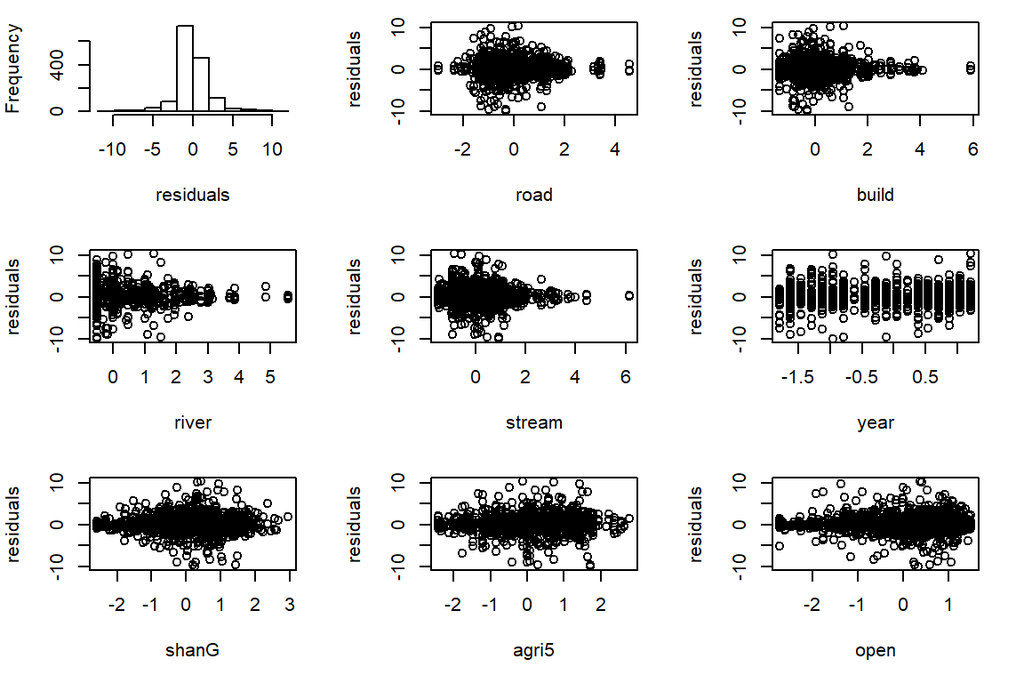

```r
op<-par(mfrow=c(3,3),mar=c(5,4,1,2))
E<-resid(M2)
hist(E, xlab = "residuals",main = "")
plot(dataS$Aroad,E,xlab = "road",ylab="residuals")
plot(dataS$Abuild,E,xlab = "build",ylab="residuals")
plot(dataS$Ariver,E,xlab = "river",ylab="residuals")
plot(dataS$Astream,E,xlab = "stream",ylab="residuals")
plot(dataS$year,E,xlab = "year",ylab="residuals")
plot(dataS$shanG,E,xlab = "shanG",ylab="residuals")
plot(dataS$agri5,E,xlab = "agri5",ylab="residuals")
plot(dataS$open,E,xlab = "open",ylab="residuals")
```

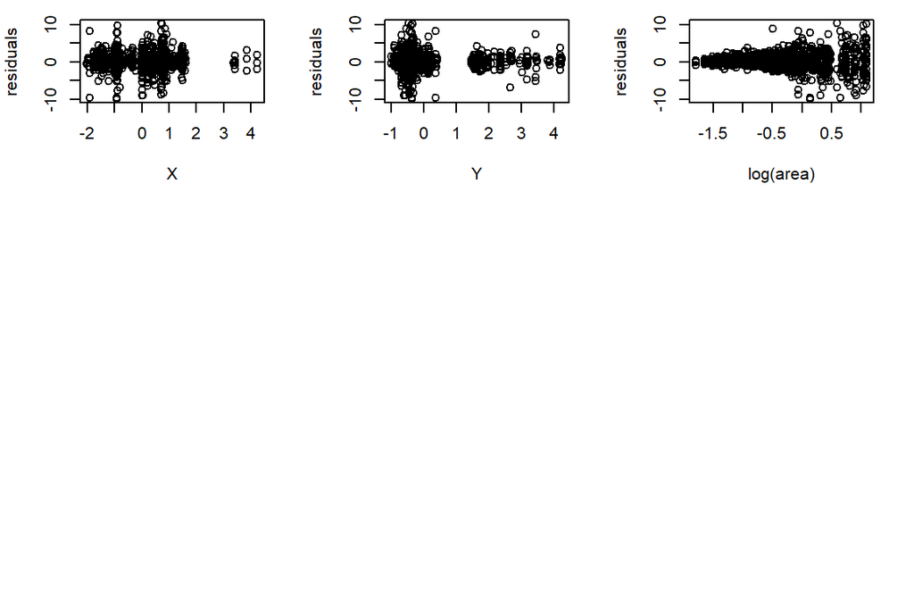

```r
plot(dataS$X,E,xlab = "X",ylab="residuals")
plot(dataS$Y,E,xlab = "Y",ylab="residuals")
plot(log(dataS$area),E,xlab = "log(area)",ylab="residuals")
par(op)
```

Pinta-alan laittaminen kovariaatiksi ei näytä muuttuvan tuloksia pääpiirteissään. Log(area) on merkitsevä. Mutta sen residuaaleissa on tötterökuvio.

### 2.2.3 GAM-malli, Tweedie

Päätettiin kokeilla mallinnusta niin, että selitettävänä muuttujana onkin reviirien tiheys. Näin osapopulaatioiden vaihteleva pinta-ala saadaan paremmin huomioitua. Osapopulaatiohan oli jo aikaisemminkin random-mmuuttujana, joten pinta-alan aiheuttama vaihtelu muuttujissa oli huomioitu jo jollain tasolla, mutta ei ehkä riittävästi.

Edelleen pienten rakenteiden lukumäärä tai pituudet on suhteutettu osapopulaation pinta-alaan. Mietin, tuleeko pinta-ala tässä tapauksessa huomioitua kahteen kertaan?

Tweedie-asiaa [täällä](https://stat.ethz.ch/R-manual/R-patched/library/mgcv/html/Tweedie.html) ja mgcv-paketista [täällä](https://people.maths.bris.ac.uk/~sw15190/mgcv/tampere/mgcv.pdf) ja [täällä](https://cran.r-project.org/web/packages/mgcv/mgcv.pdf). “Tweedie is an alternative to quasi when var(y) = φµp , 1 < p < 2, and a full distribution is required (for a non-negative real response).”

Luodaan uusi muuttuja ‘terriD’, joka on reviirien lkm jaettuna osapopulaation pinta-alalla (reviiriä/km2):

```r
#reviirien tiheys
dataS$terriD=dataS$terri/dataS$area
summary(dataS$terriD)
```

```
##    Min. 1st Qu.  Median    Mean 3rd Qu.    Max.
##   0.000   0.000   2.770   3.404   5.513  24.446
```

Plotataan aineisto uudelleen, kaksi kuvaajaa:

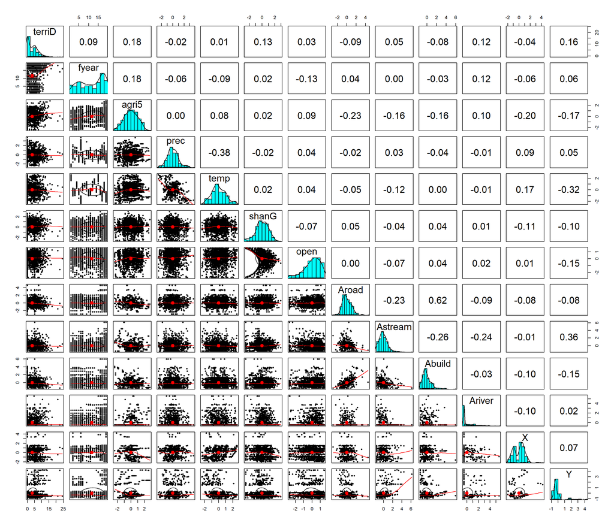

```r
#relationships
pairs.panels(dataS[,c("terriD","fyear","agri5","prec","temp","shanG","open","Aroad","Astream","Abuild","Ariver","X","Y")])
```

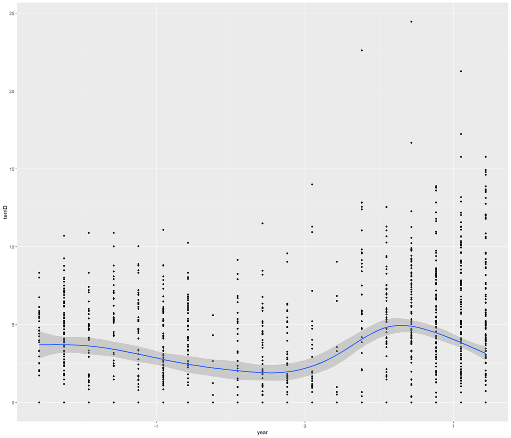

```r
ggplot(dataS, aes(x=year,y=terriD))+ geom_point() + geom_smooth()
```

Reviiritiheys mennyt alas, ylös ja alas.

Sadanta ja lämpötila negatiivisesti korreloituneita.

Mallien sovitus: Vaikea löytää esimerkkejä. Tässä yksi: [esim1](https://gist.github.com/gavinsimpson/6d05af9186b9f9419cca5a4507af3aa0).

Jotta saisin random-rakenteen huolettomasti rakennettua, haluaisin käyttää gamm-funktiota. Mutta silloin Tweedie-jakaumaa käyttäessä pitää pystyä määrittämään ko. jakaumalle p-arvo. En löydä ohjeita siitä, miten p-arvoa voisi lähteä arvioimaan. Ehkä kokeilemalla?

Toinen vaihtoehto on sovittaa malli gam-funktiolla, jolloin Tweedie-jakauma arvioi p-arvon itse. Tällöin random-rakenne pitää rakentaa hieman erilailla.

Muuttujan voi laittaa random-tekijäksi myös määrittämällä se smootherissa: s(…,bs=“re”) Lue [tämä](https://stat.ethz.ch/R-manual/R-devel/library/mgcv/html/random.effects.html) ja [tämä](https://stats.stackexchange.com/questions/197952/two-methods-of-adding-random-effects-to-a-gam-give-very-different-results-why-i). Näin voi käyttää gam-funktiota, jolloin family=tw (eikä Tweedie) eikä Tweedien p-arvoa tarvitse määrittää.

Näin aluksi vain koordinaatit X ja Y saavat smootherin.

```r
G1=gam(terriD ~  year + s(fyear,bs="re") + s(id,bs="re"), data=dataS, family=tw, REML=FALSE)

G2=gam(terriD ~  year + agri5 + Abuild + Astream + Aroad + Ariver + s(Y) + s(X) + s(fyear,bs="re") + s(id,bs="re"), data=dataS, family=tw, REML=FALSE)

G3=gam(terriD ~ agri5 + Abuild + Astream + Aroad + Ariver + s(Y) + s(X) + year*temp + year*prec + s(fyear,bs="re") + s(id,bs="re"), data=dataS, family=tw, REML=FALSE)

G4=gam(terriD ~ agri5 + Abuild + Astream + Aroad + Ariver + s(Y) + s(X) + year*shanG + year*open + s(fyear,bs="re") + s(id,bs="re"), data=dataS, family=tw, REML=FALSE)

G5=gam(terriD ~ agri5 + Abuild + Astream + Aroad + Ariver + s(Y) + s(X) + year*shanG + year*open + year*temp + year*prec + s(fyear,bs="re") + s(id,bs="re"), data=dataS, family=tw, REML=FALSE)

AIC(G1,G2,G3,G4,G5)
```

```
##          df      AIC
## G1 237.4910 6052.945
## G2 219.9643 5998.680
## G3 222.7150 6001.346
## G4 217.4522 6007.885
## G5 220.1654 6010.481
```

G2 malli saa pienimmän AIC arvon.